# ⭐⭐ Add dynamic elements to reports

📋 Instructions

Author

Affiliation

Hélène Langet

Swiss TPH Research-IT

Published

March 3, 2025

This exercise builds on the previous exercise where you learnt to build a simple MS Word report ⭐.

## 1 Objectives 🎯

- You are tasked with generating a simple analytically reproducible report on a fictitious outbreak;
- If you have generated the simple MS Word report as in Exercise 3, continue working on the same Quarto notebook you already modified. Otherwise, download the files `df1.RData` and `exercise4.qmd` using the links provided on the right-hand side of this page. For simplicity, please put these two files under the same folder and open the Quarto notebook in RStudio.
- Complete each of the following tasks and render the document after each task or set of tasks to track your progress;
- All text formatted in bold is a placeholder and should be replaced with appropriate automated calculations or cross-references;
- The final output should be a Microsoft (MS) Word report, containing all required tables, figures, corresponding captions and cross-references, and formatted with the Swiss TPH template.

## 2 Improve navigation and readability

- Insert a table of contents to the rendered MS Word document;
- Automatically number the different sections of the rendered MS Word document;
- Configure the table of contents to only display two levels of section headings.

**Tip**

- See Quarto documentation about [table of contents](https://quarto.org/docs/output-formats/ms-word.html#table-of-contents)

## 3 Implement dynamic calculations

- Change the date `2023-12-31` to the date at which the MS Word document was last rendered;
- Format the date at which the MS Word document was last rendered to display it with the format `December 31, 2023`;

**Tip**

- See Quarto documentation about [date formatting](https://quarto.org/docs/reference/dates.html#date-formatting)
- See Quarto documentation about [dynamic dates](https://quarto.org/docs/reference/dates.html#date-parsing)
- Replace the placeholder text in bold with the automated calculation of the outbreak start and end dates;

> “*The outbreak ran from **date** to **date***”
- Replace the placeholder text in bold with the automated calculation of the number of cases, confirmed cases and deaths. (Hint: We suggest to calculate these numbers in chunks in order to keep inline code short.)

> “*Over the studied period, there were **N** cases, including **N** confirmed cases and **N** confirmed deaths.*”

**Tip**

- See Quarto documentation about [inline code](https://quarto.org/docs/computations/inline-code.html)

## 4 Reference tables

#### Table 1

- Assign a label to the table summarising the demographic characteristics and outcome frequency of all cases;
- Replace the placeholder text in bold with a cross-reference to the table.

> “**cross-reference** provides a summary of the demographic characteristics and the outcome proportion for the overall population”

#### Table 2

- Assign a label to the table summarising the demographic characteristics of individuals who died versus those who are still alive;
- Replace the placeholder text in bold with a cross-reference to the table.

> “*while **cross-reference** compares the demographic characteristics of individuals who died versus those who are still alive*”

#### Table 3

- Assign a label to the table summarizing the odds ratios from the logistic regression model;
- Replace the placeholder text in bold with a cross-reference to the table

> “The results of the logistic regression model are summarized in the formatted regression table, which is presented in **cross-reference**.”

**Tip**

- See [Quarto documentation about table cross-references](https://quarto.org/docs/authoring/tables.html#cross-references)

**Important**

- There is a [known issue](https://github.com/quarto-dev/quarto-cli/issues/10587) with formatting `gt` and `gtsummary` tables in MS Word, particularly when adding captions (thank you to Zhihan for raising this). This documented bug can cause rendering problems. To avoid this, please convert your `gt` or `gtsummary` tables to `flextable` before generating the final document.

## 5 Reference figures

#### Figure 1

- Assign a label to the figure;
- Replace the placeholder text in bold with a cross-reference to the figure;

> “**cross-reference** illustrates the outbreak’s progression, which can be divided into distinct phases.”
- Adjust the dimensions of the figure until you are happy with them.

**Tip**

- See [Quarto documentation about figure cross-references](https://quarto.org/docs/authoring/cross-references.html#computations)
- See [`fig-width` and `fig-height`](https://quarto.org/docs/computations/execution-options.html#figure-options) options to adjust figure dimensions

## 6 Reference code chunks

- Add a caption to the code chunk for your R implementation of the logistic regression;
- Assign a label to the code chunk;
- Replace the placeholder text in bold with a cross-reference to the code chunk.

**Tip**

- See [Quarto documentation about code chunk cross-references](https://quarto.org/docs/authoring/cross-references.html#code-listings)

## 7 Add bibliographic references

- Create a bibliography (BibTeX) file `my_biblio.bib` in the same folder as your Quarto notebook;
- Link the BibTeX file by adding it to the YAML header of your Quarto notebook;
- Add a new reference for 10.1016/S0140-6736(24)02669-2 in the BibTeX file;
- Create a new section named `Background` in your Quarto notebook, after the `Overview` section and before the `Population` section;
- Insert the following sentence into the `Background` section, and replace the placeholder text in bold with the correct citation key from your BibTeX file.

> “**citation** describes trends in suspected and confirmed monkeypox virus cases in the Democratic Republic of Congo using epidemiological and laboratory surveillance data collected from 2010 to 2023.”

**Tip**

- You can generate the BibTeX entry from the DOI using citation management tools;
- See [Quarto documentation about citations](https://quarto.org/docs/authoring/citations.html) for guidance on formatting references;
- If you are not familiar with BibTeX files or programming, Quarto’s visual mode offers user-friendly tools for managing citations, allowing you to handle most of the previous steps automatically.

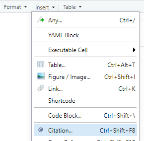

## 8 Format MS Word reports with styles

- Apply the Swiss TPH template `swisstph_template.docx` to your rendered MS Word report;
- To go further, try creating your own custom Word template and apply it to your report to explore how MS Word styles can be personalized.

**Tip**

- See [Quarto documentation about Word templates](https://quarto.org/docs/output-formats/ms-word-templates.html);
- To create a template with customized MS Word styles, you will need to start with a Quarto-rendered MS Word report. This is because not all MS Word styles are supported by Quarto, and starting from a rendered report ensures better compatibility.